# **Top Anime Analysis**

### *Kim Santos*

- *Introduction*
- *Set-Up*
- *Data Wrangling*
- *Exploratory Analysis*
- *Analysis Summary*
- *Analysis Discussion*
- *Conclusion*

## **Introduction**

Anime, to put it simply, is Japanese cartoon. Japanese animation has their own artistic style and has a variety of genres. Anime has been popular for so many years and watched amongst the world. We can find lots of animes and their information from many sources, one of them being from My Anime List (MAL). Mall is one of the largest anime databases for end users to interact with in ordre to get information. There are also users within the community to provide daily updates and information about certain animes. Such information that can be obtained are: **titles, scores, genres, types, episodes, status, aired, premiered, broadcasts, producers, licensors, studios, sources, duration, rating, popularity, members, favorite and rank.**

### **Investigation**

This project will explore and analyze data obtained from the 'Top Anime' section in MAL by using its database. The data has already been web scraped and turned into a .csv file from a different .ipynb file and can be found https://github.com/santoskim/My-Anime-List/blob/main/MALTopAnimeWebScrape.ipynb. The objective of this analysis is to investigate how and where animes are distributed amongst variables. We will find this out by creating and answering research questions

### **Research Questions:**

> What is the anime frequency in each **Type, Source** and **Rating** categories?  
> What is the relationship between **Score** and **Members**?  
> What is the distribution like in **Score** and **Members** between categories **Type, Source** and **Rating**?  
> What is the anime frequency in each **Genre**? What are each **Genres** average **Scores**?  
> When did **Genres** began and their frequency over the years?  
> What is the anime frequency in each **Studio**? What is their average **Scores**?  
> When did **Studios** began? What is their frequency production in animes over the years?

## **Set Up**

The necessary libraries and its packages will be imported as they will be needed throughout the project. This will allow statements for data manipulation, analyzation, visualization and more to be performed and executed.

```python
# manipulate + analyze data
import pandas as pd
from pandas import Series

# numerical computation functions
import numpy as np

# providing MATLAB-like interface; provides data visualization
import matplotlib.pyplot as plt

# provides data visualization; complements matplotlib
import seaborn as sns
```

## **Data Wrangling**

This section loads the 4,000+ data that was scraped and collected from https://myanimelist.net/. When the dataset is loaded, we will look at its overview to get a general idea about what we are working with. Then we will see what can be done to clean and format the data to make it appropriate for analysis.

Majority of the dataset was previously wrangled through MS Excel. You may find the original raw data here: https://github.com/santoskim/My-Anime-List/blob/main/4K%20Anime%20Raw.csv  
The following information is what was wrangled in MS Excel:

> Split Title between the anime's Japanese and English title: **Title, English_Title**  
> Split Aired from when the anime first aired and when it finished: **Start_Date, End_Date**  
> Convert the Duration of hours, minutes, and seconds into a total of minutes **Duration_Minutes**  
> Remove commas from **Popularity, Members,** and **Favorite**  
> Remove duplicate data that contains the same Title

### **This section will wrangle the following**:

1. Identify fields that contain a certain string and drop their data row.

> Episodes: 'Unknown'</br> Start_Date: 'Not available' </br> Studios: 'None found, add some'

2. Change object data types

> object -> to_numerical: Popularity, Members, Favorites, Ranked, Episodes </br> object -> to_date: Start_Date, End_Date

3. Drop columns not needed for this project

#### Loading the data 4k Anime .csv file

```python
# define and load the Top 4k Anime Series data from the desktop
mal = pd.read_csv('/Users/kimochi/Desktop/4k Anime.csv')
```

#### Data Overview

```python
# An overview of information and the first 5 rows of the dataframe are executed
mal.info()
mal.head()
```

```
<class 'pandas.core.frame.DataFrame'>
RangeIndex: 4130 entries, 0 to 4129
Data columns (total 21 columns):
 #   Column            Non-Null Count  Dtype
---  ------            --------------  -----
 0   Title             4130 non-null   object
 1   English_Title     1952 non-null   object
 2   Score             4130 non-null   float64
 3   Genres            4130 non-null   object
 4   Type              4130 non-null   object
 5   Episodes          4130 non-null   object
 6   Status            4130 non-null   object
 7   Start_Date        4130 non-null   object
 8   End_Date          2501 non-null   object
 9   Premiered         1937 non-null   object
 10  Broadcast         1946 non-null   object
 11  Producers         4130 non-null   object
 12  Licensors         4130 non-null   object
 13  Studios           4130 non-null   object
 14  Source            4130 non-null   object
 15  Duration_Minutes  4130 non-null   float64
 16  Rating            4130 non-null   object
 17  Popularity        4130 non-null   int64
 18  Members           4130 non-null   int64
 19  Favorites         4130 non-null   int64
 20  Ranked            4130 non-null   int64
dtypes: float64(2), int64(4), object(15)
memory usage: 677.7+ KB
```

|  | Title | English_Title | Score | Genres | Type | Episodes | Status | Start_Date | End_Date | Premiered | ... | Producers | Licensors | Studios | Source | Duration_Minutes | Rating | Popularity | Members | Favorites | Ranked |
| --- | --- | --- | --- | --- | --- | --- | --- | --- | --- | --- | --- | --- | --- | --- | --- | --- | --- | --- | --- | --- | --- |
| 0 | Fullmetal Alchemist: Brotherhood | NaN | 9.16 | Action, Military, Adventure, Comedy, Drama, Ma... | TV | 64 | Finished Airing | 4/5/2009 | 7/4/2010 | Spring 2009 | ... | Aniplex, Square Enix, Mainichi Broadcasting Sy... | Funimation, Aniplex of America | Bones | Manga | 24.0 | R - 17+ (violence & profanity) | 3 | 2565409 | 182220 | 1 |
| 1 | Gintama: The Final | NaN | 9.10 | Action, Sci-Fi, Comedy, Historical, Parody, Dr... | Movie | 1 | Finished Airing | 1/8/2021 | NaN | NaN | ... | TV Tokyo, Warner Bros. Japan | Eleven Arts | Bandai Namco Pictures | Manga | 104.0 | PG-13 - Teens 13 or older | 2255 | 58201 | 1619 | 2 |
| 2 | Shingeki no Kyojin Season 3 Part 2 | Attack on Titan Season 3 Part 2 | 9.10 | Action, Drama, Fantasy, Military, Mystery, Sho... | TV | 10 | Finished Airing | 4/29/2019 | 7/1/2019 | Spring 2019 | ... | Production I.G, Dentsu, Mainichi Broadcasting ... | Funimation | Wit Studio | Manga | 23.0 | R - 17+ (violence & profanity) | 36 | 1474599 | 42129 | 3 |
| 3 | Steins;Gate | NaN | 9.10 | Sci-Fi, Psychological, Drama, Thriller | TV | 24 | Finished Airing | 4/6/2011 | 9/14/2011 | Spring 2011 | ... | Frontier Works, Media Factory, Movic, AT-X, Ka... | Funimation | White Fox | Visual novel | 24.0 | PG-13 - Teens 13 or older | 11 | 2011149 | 154736 | 4 |
| 4 | Fruits Basket: The Final | NaN | 9.09 | Slice of Life, Comedy, Supernatural, Drama, Ro... | TV | 13 | Finished Airing | 4/6/2021 | 6/29/2021 | Spring 2021 | ... | TV Tokyo, TV Osaka, Nihon Ad Systems, Hakusens... | Funimation | TMS Entertainment | Manga | 23.0 | PG-13 - Teens 13 or older | 722 | 233888 | 10260 | 5 |

5 rows × 21 columns

#### 1. Identify unnecessary fields that contain a certain string and drop their data row.

> Episodes: 'Unknown'  
> Start_Date: 'Not available' </br> Studios: 'None found, add some'

```python
# Dropping strings that contain 'Unknown' from Episodes
mal = mal[~mal['Episodes'].str.contains('Unknown')]

# Dropping strings that contain 'Not available' from 'Start_Date'
mal = mal[~mal['Start_Date'].str.contains('Not available')]

# Droping columns that contain 'Not available, add some' from Studios
mal = mal[~mal['Studios'].str.contains('None found, add some')]
```

#### 2. Change object data types

```python
#  data types changed
mal['Members'] = pd.to_numeric(mal['Members'])
mal['Favorites'] = pd.to_numeric(mal['Favorites'])
mal['Episodes'] = pd.to_numeric(mal['Episodes'])
mal['Start_Date'] = pd.to_datetime(mal['Start_Date'])
mal['End_Date'] = pd.to_datetime(mal['End_Date'])
```

#### 3. Drop columns not needed for this project

```python
# use 'drop' function to remove the columns
mal.drop(['English_Title', 'End_Date','Status', 'Broadcast', 'Licensors', 'Premiered'], axis = 1, inplace = True)
```

#### Updated Data Overview

```python
mal.info()
mal.head()
```

```
<class 'pandas.core.frame.DataFrame'>
Int64Index: 3934 entries, 0 to 4129
Data columns (total 15 columns):
 #   Column            Non-Null Count  Dtype
---  ------            --------------  -----
 0   Title             3934 non-null   object
 1   Score             3934 non-null   float64
 2   Genres            3934 non-null   object
 3   Type              3934 non-null   object
 4   Episodes          3934 non-null   int64
 5   Start_Date        3934 non-null   datetime64[ns]
 6   Producers         3934 non-null   object
 7   Studios           3934 non-null   object
 8   Source            3934 non-null   object
 9   Duration_Minutes  3934 non-null   float64
 10  Rating            3934 non-null   object
 11  Popularity        3934 non-null   int64
 12  Members           3934 non-null   int64
 13  Favorites         3934 non-null   int64
 14  Ranked            3934 non-null   int64
dtypes: datetime64[ns](1), float64(2), int64(5), object(7)
memory usage: 491.8+ KB
```

|  | Title | Score | Genres | Type | Episodes | Start_Date | Producers | Studios | Source | Duration_Minutes | Rating | Popularity | Members | Favorites | Ranked |
| --- | --- | --- | --- | --- | --- | --- | --- | --- | --- | --- | --- | --- | --- | --- | --- |
| 0 | Fullmetal Alchemist: Brotherhood | 9.16 | Action, Military, Adventure, Comedy, Drama, Ma... | TV | 64 | 2009-04-05 | Aniplex, Square Enix, Mainichi Broadcasting Sy... | Bones | Manga | 24.0 | R - 17+ (violence & profanity) | 3 | 2565409 | 182220 | 1 |
| 1 | Gintama: The Final | 9.10 | Action, Sci-Fi, Comedy, Historical, Parody, Dr... | Movie | 1 | 2021-01-08 | TV Tokyo, Warner Bros. Japan | Bandai Namco Pictures | Manga | 104.0 | PG-13 - Teens 13 or older | 2255 | 58201 | 1619 | 2 |
| 2 | Shingeki no Kyojin Season 3 Part 2 | 9.10 | Action, Drama, Fantasy, Military, Mystery, Sho... | TV | 10 | 2019-04-29 | Production I.G, Dentsu, Mainichi Broadcasting ... | Wit Studio | Manga | 23.0 | R - 17+ (violence & profanity) | 36 | 1474599 | 42129 | 3 |
| 3 | Steins;Gate | 9.10 | Sci-Fi, Psychological, Drama, Thriller | TV | 24 | 2011-04-06 | Frontier Works, Media Factory, Movic, AT-X, Ka... | White Fox | Visual novel | 24.0 | PG-13 - Teens 13 or older | 11 | 2011149 | 154736 | 4 |
| 4 | Fruits Basket: The Final | 9.09 | Slice of Life, Comedy, Supernatural, Drama, Ro... | TV | 13 | 2021-04-06 | TV Tokyo, TV Osaka, Nihon Ad Systems, Hakusens... | TMS Entertainment | Manga | 23.0 | PG-13 - Teens 13 or older | 722 | 233888 | 10260 | 5 |

The wrangling now serves a clean, appropriate and valauable structure for the upcoming analyses. The updated overview fortunately resulted in no null values, which will provide more precise results for the computation and statistical analyses.

## **Exploratory Analysis**

This section will explore the newly cleaned dataframe and answer the research questions that were encountered in the beginning of this project. Statistical analyses and data visualizations are implemented to provide a clear understanding for the questions.

### **Exploring the data**

#### **Descriptive Stats**

```python
mal.describe()
```

|  | Score | Episodes | Duration_Minutes | Popularity | Members | Favorites | Ranked |
| --- | --- | --- | --- | --- | --- | --- | --- |
| count | 3934.000000 | 3934.000000 | 3934.000000 | 3934.000000 | 3.934000e+03 | 3934.000000 | 3934.000000 |
| mean | 7.479664 | 15.752415 | 35.772369 | 3108.997458 | 1.449950e+05 | 1920.296390 | 2039.072191 |
| std | 0.430756 | 39.197560 | 29.834031 | 2442.719795 | 2.732162e+05 | 8232.682644 | 1189.476108 |
| min | 6.890000 | 1.000000 | 0.000000 | 1.000000 | 5.330000e+02 | 0.000000 | 1.000000 |
| 25% | 7.150000 | 1.000000 | 23.000000 | 1148.250000 | 1.428975e+04 | 26.000000 | 1008.250000 |
| 50% | 7.380000 | 12.000000 | 24.000000 | 2543.000000 | 4.636200e+04 | 120.500000 | 2026.500000 |
| 75% | 7.717500 | 20.000000 | 30.000000 | 4501.250000 | 1.475560e+05 | 721.500000 | 3067.750000 |
| max | 9.160000 | 1787.000000 | 168.000000 | 12589.000000 | 3.007722e+06 | 182220.000000 | 4130.000000 |

First we take a look into a descriptive statistical analysis. It will describe where numerical variables land in terms of the average, standard deviation, minimum, maximum, and quartiles. This helps give an idea what we are working with for each variable as a whole individually. It is important to take in context when observing this descriptive analysis and what the variables mean. For example, it does not make sense to know the average of **Popularity, Favorites, and Ranked** when those variables are not for its purpose. However, it does make sense to know who has the highest (min) and lowest (max) ranking in Popularity, Favorites and Ranked.

#### **Heatmap**

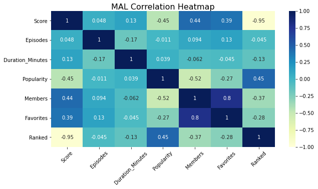

```python
#correlation between numerical variables
fig, ax = plt.subplots(figsize=(10,5))
mal_corr = sns.heatmap(mal.corr(), vmin=-1, vmax=1, annot=True, cmap="YlGnBu")
mal_corr.set_title('MAL Correlation Heatmap', fontdict={'fontsize':16}, pad=1);

plt.xticks(rotation=45)
plt.show()
```

The heatmap displays the correlation between numerical variables in the dataset. There is a negative and positive relationship based on the light and dark color each block has. Those that fall in the negative relationship contains a negative value with a light color block, and it will increase positively as it progresses towards a positive value and darker color block.

The heatmap shows the **Ranked** and **Score** variables have the most negative correlated relationship. An assumption for this reason is due to the meaning behind the variables. Animes are placed in rankings based on the score they are given by the community. If animes are scored closed to 10, they are placed in rankings close to 1, and vice versa if they are scored lower than 10 then they are ranked away from 1.

The positive relationships who hold a positive 1 value will be ignored because it regards to variables being correlated to their same variable. The next highest positive value, which will indicate the most positive correlated relationship are from **Members + Favorites**. An assumption may be that members who enjoyed the anime they watched would also add it as a favorite for themselves. Thus, creating a positive correlation.

### **What is the anime frequency in each** Type, Source **and** Rating **categories?**

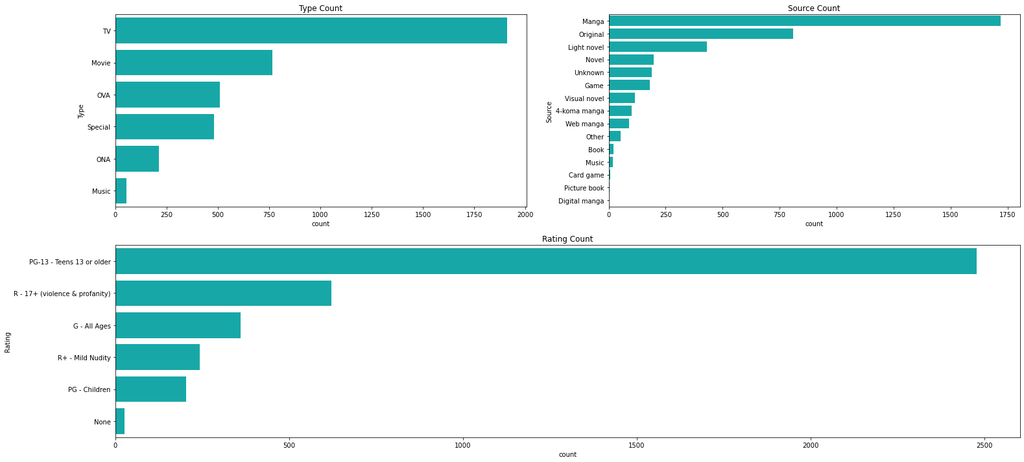

```python
# Create 3 count plots from descending order for each variable categories
f, ax = plt.subplots(figsize=(25, 12))
plt.subplot(2, 2, 1)
type_count_plot = sns.countplot(y = 'Type', data = mal, order = mal['Type'].value_counts().index, color = 'c').set_title("Type Count")

plt.subplot(2, 2, 2)
source_count_plot = sns.countplot(y = 'Source', data = mal, order = mal['Source'].value_counts().index, color = 'c').set_title("Source Count")

plt.subplot(2, 1, 2)
rating_count_plot = sns.countplot(y = 'Rating', data = mal, order = mal['Rating'].value_counts().index, color = 'c').set_title("Rating Count")

plt.show()
```

Count plots were created from descending order for **Type, Source**, and **Rating**. This identifies which categories for each variable produced the most amount of animes.

Based on the three graphs, we may say animes are more focused on mangas that are PG-13 and would produce them into television.

### **What is the relationship like between 'Score' and 'Members'**

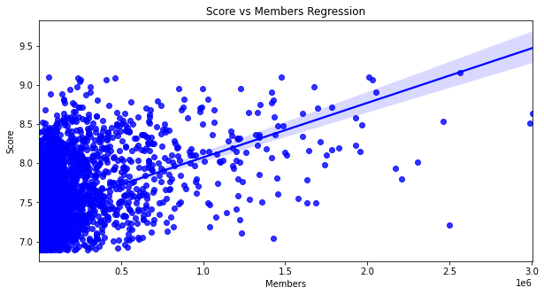

```python
# creating linear regression plot
f, ax = plt.subplots(figsize=(10, 5))
score_member_reg_plot = sns.regplot(x='Members', y='Score', data=mal,  color='Blue').set_title("Score vs Members Regression")
```

A linear regression plot shows there is a positive correlation from the way members score the animes they watch, where majority of the members score their animes from 7-8.5.

### **What is the distribution like in** Score **and** Members **between categories** Type, Source **and** Rating**?**

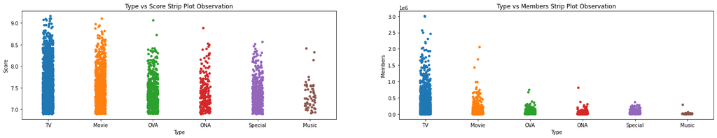

```python
# strip plot for 'Type'
fig, ax = plt.subplots(1, 2, figsize = (25, 4))
type_score_strip_plot = sns.stripplot(x='Type', y='Score', data=mal, jitter=True, ax=ax[0]).set_title("Type vs Score Strip Plot Observation")
type_members_strip_plot = sns.stripplot(x='Type', y='Members', data=mal, jitter = True, ax=ax[1]).set_title("Type vs Members Strip Plot Observation")
plt.show()
```

The strip plots show a distribution where **Score** and **Members** lie in each categories for **Type**. We see **TV** category contains the most distrubtion where animes are **Scored** and **Rated** while the **Movie** category comes in second. The least category that has the least is **Music**

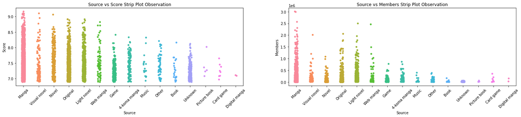

```python
# strip plot for 'Source'
fig, ax = plt.subplots(1, 2, figsize = (25, 4))
plt.subplot(1, 2, 1)
source_score_strip_plot = sns.stripplot(x='Source', y='Score', data=mal, jitter=True).set_title("Source vs Score Strip Plot Observation")
plt.xticks(rotation=45)

plt.subplot(1, 2, 2)
source_members_strip_plot = sns.stripplot(x='Source', y='Members', data=mal, jitter = True).set_title("Source vs Members Strip Plot Observation")
plt.xticks(rotation=45)

plt.show()
```

The strip plots here show the distrubtion of **Score** and **Members** through **Sources**. **Manga** contains the most distrubtion in terms of **Scores** and **Members** that animes frequent in while **Original/ Light Novel** come next. **Digital Manga** comes in last with less frequencies.

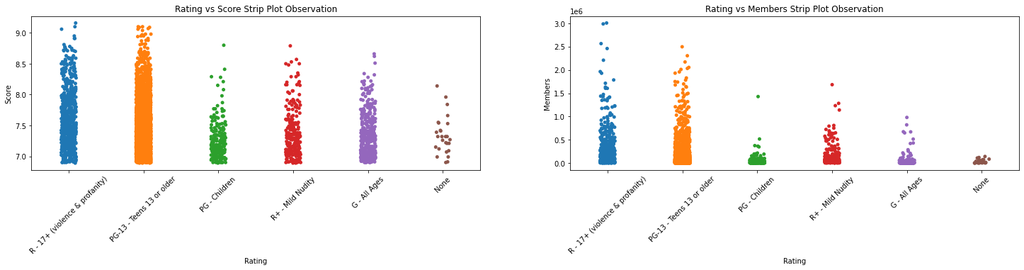

```python
# strip plot for 'Rating'
fig, ax = plt.subplots(1, 2, figsize = (25, 4))
plt.subplot(1, 2, 1)
rating_score_strip_plot = sns.stripplot(x='Rating', y='Score', data=mal, jitter=True).set_title("Rating vs Score Strip Plot Observation")
plt.xticks(rotation=45)

plt.subplot(1, 2, 2)
rating_members_strip_plot = sns.stripplot(x='Rating', y='Members', data=mal, jitter = True).set_title("Rating vs Members Strip Plot Observation")
plt.xticks(rotation=45)

plt.show()
```

The strip plots show the distribution of **Score** and **Members** within **Rating**. **PG-13** has the most frequencies while **None** has the least.

#### Overall strip plot analysis

The three strip plots overall shows where the variables **Score** and **Members** are distributed through **Type, Source,** and **Rating**. Comparisons were shown in how well each category do where animes frequent in.

### **What is the anime frequency in each** Genre**? What are each** Genres **average** Scores**?**

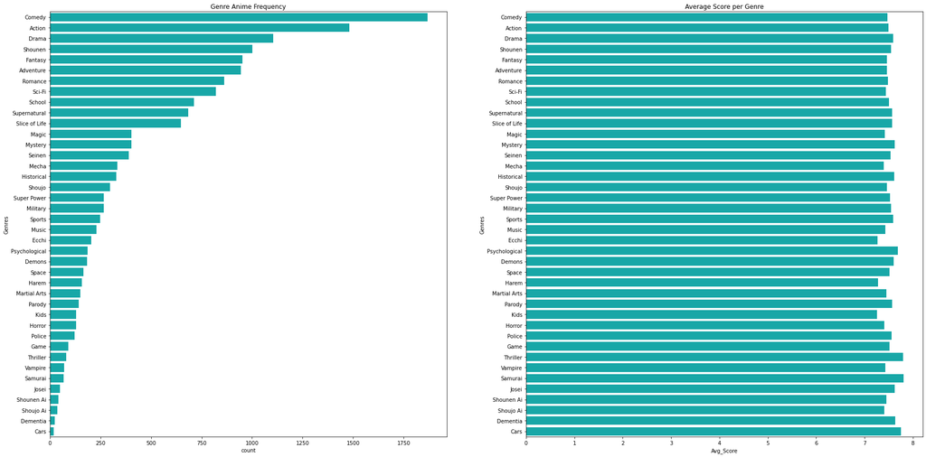

```python
# new dataframe that only includes studios, members, score, title and genres; splitting genres
mal_genres = mal[['Studios','Members', 'Score', 'Title','Genres']].copy()
mal_genres = (pd.concat( (mal_genres.Genres.str.split(', ', expand=True),
          mal_genres[['Studios','Members', 'Score', 'Title']]),
          axis=1)
   .melt(id_vars=['Studios','Members', 'Score', 'Title'], value_name='Genres')
   .dropna())
mal_genres.drop(['variable'], axis = 1, inplace = True)

# new dataframe that only includes genres, score and title; splitting genres
mal_a = mal[['Studios','Members', 'Score', 'Title', 'Genres']].copy()
mal_a = (pd.concat( (mal_a.Genres.str.split(', ', expand=True),
          mal_a[['Studios','Members', 'Score', 'Title']]),
          axis=1)
   .melt(id_vars=['Studios','Members', 'Score', 'Title'], value_name='Genres')
   .dropna()
   .drop(['variable'], axis = 1, inplace = True))

# grouping each genre, counting how many animes were produced and gathering their average
genre_count_score_avg = (mal_genres.groupby('Genres')
       .agg(count=('Title', 'size'), Avg_Score=('Score', 'mean'))
       .reset_index()
       .sort_values(['count'],ascending=False)
       .head(50))

# barplots
f, ax = plt.subplots(figsize=(30, 15))
plt.subplot(1, 2, 1)
genre_freq = sns.barplot(x="count", y="Genres", data=genre_count_score_avg, color = 'c').set_title('Genre Anime Frequency')

plt.subplot(1, 2, 2)
genre_avg_score = sns.barplot(x="Avg_Score", y="Genres", data=genre_count_score_avg, color = 'c').set_title('Average Score per Genre')
plt.show()
```

### **When did** Genres **began and their frequency over the years?**

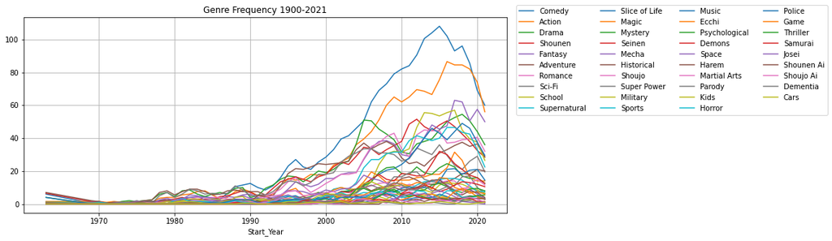

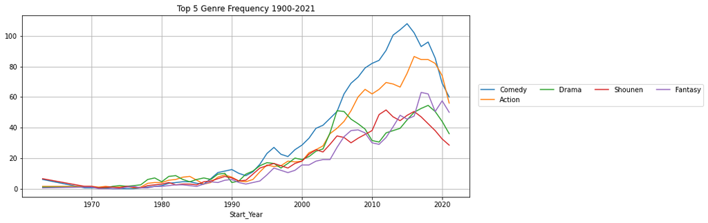

```python
mal['Start_Year'] = pd.DatetimeIndex(mal['Start_Date']).year

# creating dataframe that explodes genres
genres = mal['Genres'].str.get_dummies(sep = ", ")
mal_1 = (pd.concat([mal, genres], axis=1)
                       .drop(["Genres"], axis=1))

# Grouping Genres by year and see frequency of occurrences over the years
genres_1 = (mal_1.iloc[:, 15:-1]
              .sum()
              .sort_values(ascending=False)
              .head(50)
              .index.values
              )
genres_2 = (mal_1.iloc[:, 15:-1]
              .sum()
              .sort_values(ascending=False)
              .head(5)
              .index.values
              )
#-------
genre_occ_1 = (mal_1.iloc[:, 4:]
                .groupby("Start_Year")
                .sum()
               ).loc["1900":"2021", genres_1]
genre_occ_2 = (mal_1.iloc[:, 4:]
                .groupby("Start_Year")
                .sum()
               ).loc["1900":"2021", genres_2]
#----------

# graphing time series of genres over the years
genre_occ_plot_1 = (genre_occ_1.rolling(2)
                  .mean().plot(figsize=(12,5),
                  title="Genre Frequency 1900-2021")
                  .legend(loc=(1.01, 0.01), ncol=4, bbox_to_anchor=(1.02, 0.5)))
plt.grid()
plt.show()

genre_occ_plot_2 = (genre_occ_2.rolling(2)
                    .mean().plot(figsize=(12,5),
                    title="Top 5 Genre Frequency 1900-2021")
                    .legend(loc=(1.01, 0.01), ncol=4, bbox_to_anchor=(1.02, 0.5)))
plt.grid()
plt.show()
```

Two time series line graphs are displayed. The top graph contains all genres and the bottom graph contains the top 5 genres the holds the most frequented animes.

The top graph shows the distinction between popular and unpopular of all genres when they occured. A lot of genres has shown they are not really being used and can say they are not one of the popular ones while other genres made a rise over the years in how frequent they are used in animes.

The bottom graph gives us a more clearer detail between the top 5 genres and how they trended over the years. Comedy took the biggest jump during the 2000s, followed by action.

### **What is the anime frequency in each** Studio**? What is their average** Scores**?**

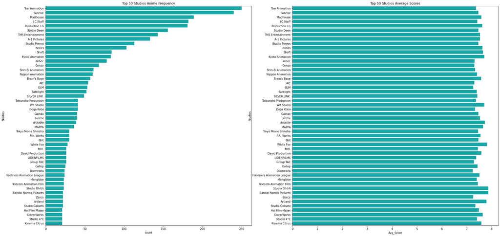

```python
# Analysis
mal_studios = mal[['Studios', 'Score', 'Members','Title', 'Source', 'Type', 'Rating']].copy()
mal_studios = (pd.concat( (mal_studios.Studios.str.split(', ', expand=True),
          mal_studios[['Score', 'Members','Title', 'Source', 'Type','Rating']]),
          axis=1)
   .melt(id_vars=['Score', 'Members','Title', 'Source', 'Type','Rating'], value_name='Studios')
   .dropna())
mal_studios.drop(['variable'], axis = 1, inplace = True)

# group each studio; count how many animes were produced and get average score + genres of all animes
studio_count_score_avg = (mal_studios.groupby('Studios')
       .agg(count=('Title', 'size'), Avg_Score=('Score', 'mean'))
       .reset_index()
       .sort_values(['count'],ascending=False)
       .head(50))

f, ax = plt.subplots(figsize=(30, 15))
plt.subplot(1, 2, 1)
studio_freq = sns.barplot(x="count", y="Studios", data=studio_count_score_avg, color = 'c').set_title('Top 50 Studios Anime Frequency')

plt.subplot(1, 2, 2)
studio_avg_score = sns.barplot(x="Avg_Score", y="Studios", data=studio_count_score_avg, color = 'c').set_title('Top 50 Studios Average Scores')
plt.show()
```

The two bar graphs show the anime frequencies in Studios and how Studios score in the animes they produce. There were over 100 studios present in the data frame. Animes were counted for each studio and the top 50 studios are displayed in the graph.  
Toei Animation, Sunrise, Madhouse, J.C Staff and Produection I.D take the lead for being the top 5 studios of producing over 170 animes than other studios and having average scores around 7.5.

### **When did** Studios **began? What is their frequency production in animes over the years?**

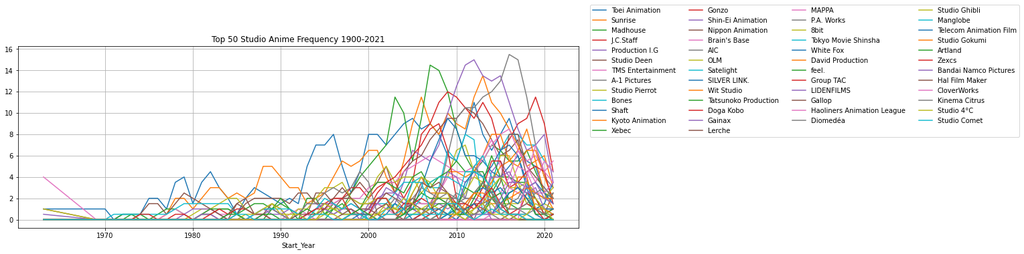

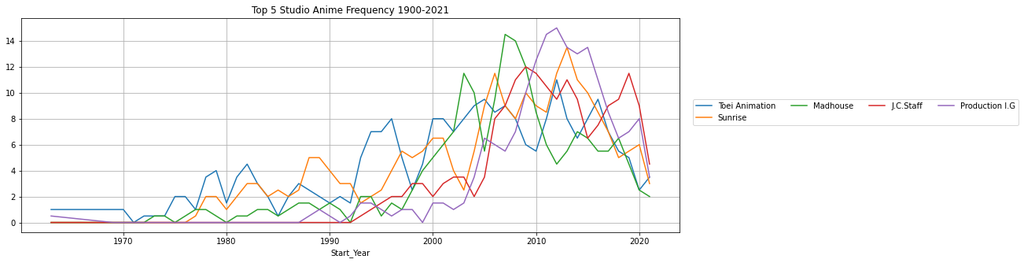

```python
# creating dataframe that explodes genres
studios = mal['Studios'].str.get_dummies(sep = ", ")
mal_3 = (pd.concat([mal, studios], axis=1)
                       .drop(["Studios"], axis=1))

# Grouping studios by year and see frequency of occurrences
studios_1 = (mal_3.iloc[:, 15:-1]
              .sum()
              .sort_values(ascending=False)
              .head(50)
              .index.values
              )
studios_2 = (mal_3.iloc[:, 15:-1]
              .sum()
              .sort_values(ascending=False)
              .head(5)
              .index.values
              )
#---
studio_occ_1 = (mal_3.iloc[:, 4:]
                .groupby("Start_Year")
                .sum()
               ).loc["1900":"2021", studios_1]

studio_occ_2 = (mal_3.iloc[:, 4:]
                .groupby("Start_Year")
                .sum()
               ).loc["1900":"2021", studios_2]
#---
# graphing time series of studios over the years
studio_occ_plot = (studio_occ_1.rolling(2)
                  .mean().plot(figsize=(15,5),
                  title="Top 50 Studio Anime Frequency 1900-2021")
                  .legend(loc=(1.01, 0.01), ncol=4, bbox_to_anchor=(1.02, 0.5)))
plt.grid()

# graphing time series of studios over the years
studio_occ_plot_2 = (studio_occ_2.rolling(2)
                  .mean().plot(figsize=(15,5),
                  title="Top 5 Studio Anime Frequency 1900-2021")
                  .legend(loc=(1.01, 0.01), ncol=4, bbox_to_anchor=(1.02, 0.5)))
plt.grid()
plt.show()
```

Two time series graphs are shown by studios and the frequency they produced animes over the years. The top graph shows many studios produced more animes compared to other studios. The second graph shows us the top 5 studios and just how many animes they created over the years. They first began creating less than 6 animes when they started and kicked off to creating even more after the 2000s.

# **Analysis Summary**

This section will discuss the overall analysis from the distribution of animes through genres and studios.

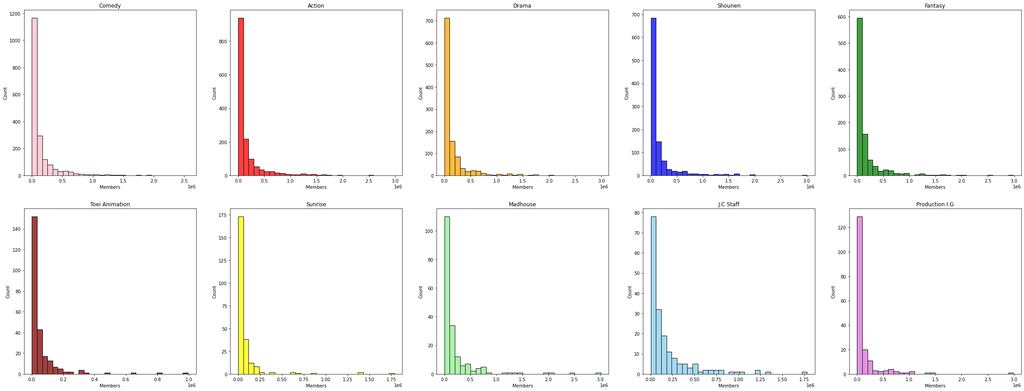

|  | Studios | count | Avg_Score | Tot_Members | Source | Type | Rating |
| --- | --- | --- | --- | --- | --- | --- | --- |
| 286 | Toei Animation | 250 | 7.372680 | 14252791 | [Manga, Original, Music, Novel, Other, Unknown, Picture book, Visual novel, Light novel, Book, Game] | [TV, Movie, Special, Music, OVA, ONA] | [PG-13 - Teens 13 or older, R - 17+ (violence & profanity), G - All Ages, PG - Children, R+ - Mild Nudity, None] |
| 266 | Sunrise | 240 | 7.473958 | 18395736 | [Manga, Original, Web manga, Novel, Unknown, Light novel, Other, Music, Game, Card game, Picture book] | [TV, Movie, Special, OVA, ONA, Music] | [PG-13 - Teens 13 or older, R - 17+ (violence & profanity), R+ - Mild Nudity, G - All Ages, PG - Children] |
| 153 | Madhouse | 189 | 7.586667 | 39915018 | [Manga, Novel, Original, Web manga, Light novel, Game, Other, Unknown, Visual novel] | [TV, Movie, OVA, Special, Music] | [PG-13 - Teens 13 or older, R+ - Mild Nudity, R - 17+ (violence & profanity), PG - Children, G - All Ages, None] |
| 122 | J.C.Staff | 182 | 7.429066 | 34612054 | [Manga, Light novel, Visual novel, Original, 4-koma manga, Web manga, Card game, Unknown, Other, Game] | [TV, Movie, Special, ONA, OVA] | [PG-13 - Teens 13 or older, R - 17+ (violence & profanity), R+ - Mild Nudity, G - All Ages, None, PG - Children] |
| 199 | Production I.G | 181 | 7.627901 | 28037923 | [Manga, Novel, Original, Unknown, Game, Web manga, Light novel, Visual novel, 4-koma manga, Other] | [TV, OVA, Movie, Special, Music, ONA] | [PG-13 - Teens 13 or older, R - 17+ (violence & profanity), R+ - Mild Nudity, PG - Children, G - All Ages, None] |

```python
# group each studio; count how many animes were produced and get average score + genres of all animes
pd.set_option('max_colwidth', None)

studio_analysis = (mal_studios.groupby('Studios')
       .agg(count=('Title', 'size'), Avg_Score=('Score', 'mean'), Tot_Members = ('Members', 'sum'), Source = ('Source', 'unique'),
            Type = ('Type', 'unique'), Rating = ('Rating', 'unique'))
       .reset_index()
       .sort_values(['count'],ascending=False)
       .head(5))

studio_genre_analysis = (mal_genres.groupby('Studios')
       .agg(count=('Title', 'size'), Genres=('Genres', 'unique'))
       .reset_index()
       .sort_values(['count'],ascending=False)
       .head(6))
studio_genre_analysis.drop(['count'], axis = 1, inplace = True)
studio_genre_analysis = studio_genre_analysis[studio_genre_analysis["Studios"].str.contains("Studio Deen")==False]

comedy = mal_genres[mal_genres['Genres'].str.match('Comedy')]
action = mal_genres[mal_genres['Genres'].str.match('Action')]
drama = mal_genres[mal_genres['Genres'].str.match('Drama')]
shounen = mal_genres[mal_genres['Genres'].str.match('Shounen')]
fantasy = mal_genres[mal_genres['Genres'].str.match('Fantasy')]

toei = mal_studios[mal_studios['Studios'].str.match('Toei Animation')]
sunrise = mal_studios[mal_studios['Studios'].str.match('Sunrise')]
madhouse = mal_studios[mal_studios['Studios'].str.match('Madhouse')]
jc = mal_studios[mal_studios['Studios'].str.match('J.C.Staff')]
ig = mal_studios[mal_studios['Studios'].str.match('Production I.G')]

f, ax = plt.subplots(figsize=(40, 15))

plt.subplot(2, 5, 1)
comedy_hist = sns.histplot(data=comedy, x="Members", color= 'pink', bins=30).set_title("Comedy")

plt.subplot(2, 5, 2)
action_hist = sns.histplot(data=action, x="Members", color = 'red', bins = 30).set_title("Action")

plt.subplot(2, 5, 3)
drama_hist = sns.histplot(data=drama, x="Members", color = 'orange', bins = 30).set_title("Drama")

plt.subplot(2, 5, 4)
shounen_hist = sns.histplot(data=shounen, x="Members", color = 'blue', bins = 30).set_title("Shounen")

plt.subplot(2, 5, 5)
fantasy_hist = sns.histplot(data=fantasy, x="Members", color = 'green', bins = 30).set_title("Fantasy")

plt.subplot(2, 5, 6)
toei_hist = sns.histplot(data= toei, x="Members", color = 'maroon', bins = 30).set_title("Toei Animation")

plt.subplot(2, 5, 7)
sunrise_hist = sns.histplot(data= sunrise, x="Members", color = 'yellow', bins = 30).set_title("Sunrise")

plt.subplot(2, 5, 8)
madhouse_hist = sns.histplot(data= madhouse, x="Members", color = 'lightgreen', bins = 30).set_title("Madhouse")

plt.subplot(2, 5, 9)
jc_hist = sns.histplot(data= jc, x="Members", color = 'skyblue', bins = 30).set_title("J.C Staff")

plt.subplot(2, 5, 10)
ig_hist = sns.histplot(data= ig, x="Members", color = 'orchid', bins = 30).set_title("Production I.G")

plt.show()
studio_analysis
```

```python
studio_genre_analysis
```

|  | Studios | Genres |
| --- | --- | --- |
| 394 | Toei Animation | [Comedy, Mystery, Action, Adventure, Drama, Sci-Fi, Demons, Fantasy, Slice of Life, Game, Mecha, Historical, Magic, Kids, Sports, Horror, Shoujo, Romance, Shounen, Psychological, Super Power, School, … |
| 353 | Sunrise | [Action, Drama, Slice of Life, Adventure, Comedy, Music, Military, Sci-Fi, Parody, Shounen, Fantasy, Mecha, Space, Game, School, Romance, Mystery, Psychological, Super Power, Magic, Kids, Ecchi, Samur… |
| 190 | Madhouse | [Action, Drama, Comedy, Mystery, Adventure, Dementia, Game, Music, Sports, Sci-Fi, Fantasy, Slice of Life, Horror, Historical, Psychological, Romance, Ecchi, Police, Shounen, Supernatural, School, Sei… |
| 152 | J.C.Staff | [Comedy, Adventure, Music, Drama, Ecchi, Action, Slice of Life, Game, Mystery, Dementia, Demons, Magic, Harem, Sci-Fi, Romance, Supernatural, Mecha, Police, Military, Josei, School, Parody, Fantasy, H… |
| 257 | Production I.G | [Comedy, Action, Slice of Life, Mystery, Military, Sports, Josei, Adventure, Shounen, Drama, Supernatural, Music, School, Sci-Fi, Romance, Mecha, Historical, Horror, Police, Demons, Psychological, Fan… |

## **Analysis Discussion**

What is being shown above are histograms from the top 5 genres and top 5 studios based on their member frequencies. Two dataframes are displayed below the histograms that involves the top 5 studios' total count of animes produced, average scores, total members and what sources, types, ratings and genres they used. The categorical columns in the dataframes has their values arranged in descending order, meaning where studios assumingly focused on the most to least from left to right of the values displayed.

### *Histograms Analysis*

From what we understand so far with genres, the top 5 are Comedy, Action, Drama, Shounen, and Fantasy who all have an average score of around 7.5. The genres gained more use in animes after the year 2000s and grew even more past 2010. The histograms we see above provides a visualization where majority of members frequent in when watch animes with those certain genres. All the genre histograms are skewed to the right, and majority frequent in members of 500,000 and less.

### *Categorical Columns Analysis*

It was seen in the analysis where animes fell into for each category in terms of the Type, Source, Ratings and Genres variables. The following will explain the categories that held the most frequencies and their frequencies in terms of score and members.

> **Type** TV  
> TV resulted in ~2,000 animes. Most members were 1 million and below and scored animes from 7-8.5.

> **Source** Manga  
> Manga resulted in ~1,750 animes. Most members were 1 million and below and scored animes from 7-9.

> **Rating** PG-13  
> PG-13 resulted in ~2,500 animes. Most members were 1.5 million and below and scored animes from 7-8.5.

The studio_analysis and studio_genre_analysis dataframes in this section lists the top 5 studios who created the most animes to least. As mentioned before, each categorical columns for the dataframes arranged values from most to least used. It can be seen for all the top 5 studios focused on producing animes based on mangas and releasing them as television series for a PG-13 audience. As for genres, the studios either included 1-2 genres that were also the top 5 genres discussed earlier.

## **Conclusion**

This analysis explored where animes frequent and what their relationship is long among variables in the dataset. We first identied animes were more frequent coming from mangas and creating them into television series for a PG-13 audience. The relationship between how many members there are in animes and how they score them showed a positive correlation. We also looked into what genres are used more and how they frequent over the years. The same goes for studios where we see how many they produced within the years.